# Reporte PCA reproducible

Author

# Nota sobre rutas

Este archivo `.qmd` está pensado para guardarse en la carpeta `bin/`.

Por eso, las rutas del código se escriben considerando que el archivo se ejecuta desde `bin/`:

- los datos se leen desde `../data/`;
- las figuras y tablas se guardan en `../results/`.

# Introducción

Este reporte presenta un análisis exploratorio de Componentes Principales (PCA) usando una tabla de datos biológicos simulados. El objetivo es explorar si las muestras presentan un patrón de agrupamiento asociado con la etapa registrada en los metadatos.

Un PCA permite resumir la variación de varias variables numéricas en nuevos ejes llamados componentes principales. En este ejemplo, los puntos representan muestras y el color indica la etapa a la que pertenece cada muestra.

El análisis debe interpretarse como una exploración inicial. Una separación visual entre grupos no demuestra por sí sola diferencias estadísticamente significativas.

# Cargar paquetes

Primero cargamos los paquetes necesarios para importar datos desde Excel, manipular tablas y construir figuras.

```r
library(readxl)
library(dplyr)
library(ggplot2)
```

# Datos utilizados

Importamos el archivo de datos desde la carpeta `data/` del proyecto.

Como este archivo `.qmd` está guardado en `bin/`, usamos `../data/` para subir un nivel y entrar a la carpeta de datos.

```r
datos <- read_excel("../data/U6_datos_pca.xlsx")
```

Revisamos la estructura general de la tabla.

```r
head(datos)
```

```
# A tibble: 6 × 8
  muestra etapa  tratamiento sitio   TAR   ARF    CO    GA
  <chr>   <chr>  <chr>       <chr> <dbl> <dbl> <dbl> <dbl>
1 M001    Etapa1 control     Norte  4.90  6.75  3.76  5.06
2 M002    Etapa1 control     Norte  4.68  6.21  3.24  4.15
3 M003    Etapa1 control     Norte  4.84  5.65  3.68  5.5
4 M004    Etapa1 control     Norte  4.40  6.60  3.77  4.97
5 M005    Etapa1 control     Norte  4.01  6.11  3.72  5.76
6 M006    Etapa1 control     Norte  4.86  6.06  5.42  7.58
```

```r
dim(datos)
```

```
[1] 900   8
```

```r
names(datos)
```

```
[1] "muestra"     "etapa"       "tratamiento" "sitio"       "TAR"
[6] "ARF"         "CO"          "GA"
```

```r
str(datos)
```

```
tibble [900 × 8] (S3: tbl_df/tbl/data.frame)
 $ muestra    : chr [1:900] "M001" "M002" "M003" "M004" ...
 $ etapa      : chr [1:900] "Etapa1" "Etapa1" "Etapa1" "Etapa1" ...
 $ tratamiento: chr [1:900] "control" "control" "control" "control" ...
 $ sitio      : chr [1:900] "Norte" "Norte" "Norte" "Norte" ...
 $ TAR        : num [1:900] 4.91 4.68 4.84 4.4 4.01 ...
 $ ARF        : num [1:900] 6.75 6.21 5.65 6.6 6.11 ...
 $ CO         : num [1:900] 3.76 3.24 3.68 3.77 3.72 ...
 $ GA         : num [1:900] 5.06 4.15 5.5 4.97 5.76 ...
```

La tabla contiene columnas de metadatos y columnas numéricas. En este ejemplo, los metadatos describen la muestra, etapa, tratamiento y sitio. Las columnas numéricas corresponden a las variables que usaremos para calcular el PCA.

# Preparación de datos

Separamos los metadatos de las variables numéricas. Los metadatos se usarán para interpretar y colorear la figura, pero no entran al cálculo del PCA.

```r
metadatos <- datos %>%
  select(muestra, etapa, tratamiento, sitio)

genes <- c("TAR", "ARF", "CO", "GA")

datos_pca <- datos %>%
  select(all_of(genes))

head(metadatos)
```

```
# A tibble: 6 × 4
  muestra etapa  tratamiento sitio
  <chr>   <chr>  <chr>       <chr>
1 M001    Etapa1 control     Norte
2 M002    Etapa1 control     Norte
3 M003    Etapa1 control     Norte
4 M004    Etapa1 control     Norte
5 M005    Etapa1 control     Norte
6 M006    Etapa1 control     Norte
```

```r
head(datos_pca)
```

```
# A tibble: 6 × 4
    TAR   ARF    CO    GA
  <dbl> <dbl> <dbl> <dbl>
1  4.90  6.75  3.76  5.06
2  4.68  6.21  3.24  4.15
3  4.84  5.65  3.68  5.5
4  4.40  6.60  3.77  4.97
5  4.01  6.11  3.72  5.76
6  4.86  6.06  5.42  7.58
```

# Análisis de Componentes Principales

Calculamos el PCA con la función `prcomp()`. Usamos `center = TRUE` y `scale. = TRUE` para centrar y escalar las variables antes del análisis. Esto ayuda a que las variables contribuyan de forma más comparable, especialmente cuando tienen escalas distintas.

```r
pca_resultado <- prcomp(
  datos_pca,
  center = TRUE,
  scale. = TRUE
)
```

# Varianza explicada

Calculamos qué porcentaje de la variación total explica cada componente principal.

```r
varianza <- pca_resultado$sdev^2
varianza_explicada <- varianza / sum(varianza)

tabla_varianza <- data.frame(
  componente = paste0("PC", seq_along(varianza_explicada)),
  varianza_explicada = varianza_explicada,
  porcentaje = varianza_explicada * 100
)

tabla_varianza
```

```
  componente varianza_explicada porcentaje
1        PC1         0.63738082  63.738082
2        PC2         0.20942028  20.942028
3        PC3         0.10682534  10.682534
4        PC4         0.04637357   4.637357
```

Guardamos los porcentajes de PC1 y PC2 para usarlos en las etiquetas de los ejes.

```r
pc1 <- round(tabla_varianza$porcentaje[1], 1)
pc2 <- round(tabla_varianza$porcentaje[2], 1)
```

# Coordenadas de las muestras

Extraemos las coordenadas de las muestras en el espacio del PCA y agregamos los metadatos para poder colorear la figura por etapa.

```r
pca_scores <- as.data.frame(pca_resultado$x)

pca_scores <- bind_cols(metadatos, pca_scores)

head(pca_scores)
```

```
# A tibble: 6 × 8
  muestra etapa  tratamiento sitio   PC1    PC2     PC3     PC4
  <chr>   <chr>  <chr>       <chr> <dbl>  <dbl>   <dbl>   <dbl>
1 M001    Etapa1 control     Norte -2.28  0.337  0.212   0.0366
2 M002    Etapa1 control     Norte -2.88  0.357 -0.0924 -0.0667
3 M003    Etapa1 control     Norte -2.37 -0.237  0.189   0.206
4 M004    Etapa1 control     Norte -2.42  0.283  0.312  -0.0320
5 M005    Etapa1 control     Norte -2.35 -0.106  0.559   0.239
6 M006    Etapa1 control     Norte -1.05 -0.738  0.970   0.148
```

# Visualización del PCA

Graficamos PC1 contra PC2. Cada punto representa una muestra y el color indica la etapa.

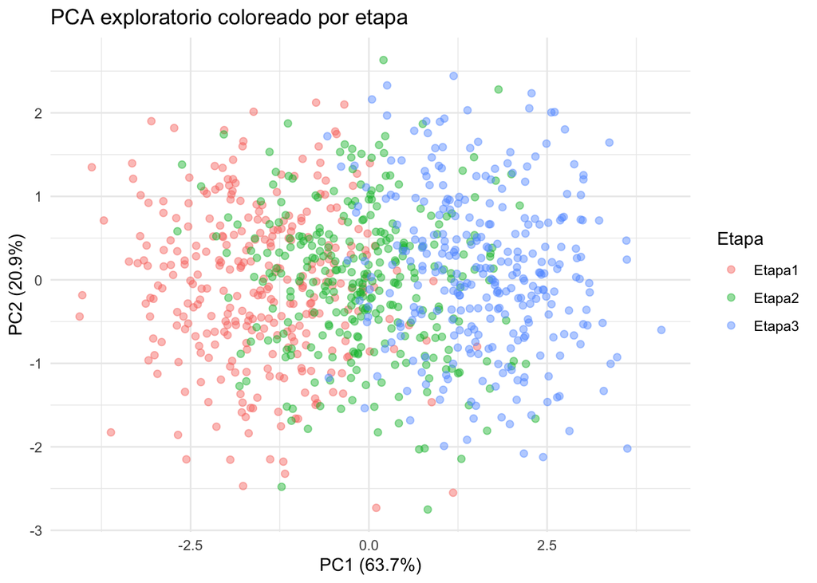

```r
pca_etapa <- ggplot(pca_scores, aes(x = PC1, y = PC2, color = etapa)) +
  geom_point(size = 1.8, alpha = 0.45) +
  labs(
    title = "PCA exploratorio coloreado por etapa",
    x = paste0("PC1 (", pc1, "%)"),
    y = paste0("PC2 (", pc2, "%)"),
    color = "Etapa"
  ) +
  theme_minimal()

pca_etapa
```

También podemos guardar la figura y las tablas principales en la carpeta `results/`.

Como este archivo `.qmd` está en `bin/`, usamos `../results/` para guardar los productos en la carpeta de resultados del proyecto.

```r
ggsave(
  filename = "../results/U6_pca_reporte_etapa.png",
  plot = pca_etapa,
  width = 7,
  height = 5,
  dpi = 300
)

write.csv(
  tabla_varianza,
  "../results/U6_pca_reporte_varianza_explicada.csv",
  row.names = FALSE
)

write.csv(
  pca_scores,
  "../results/U6_pca_reporte_scores.csv",
  row.names = FALSE
)
```

# Interpretación

El PCA muestra un patrón de separación parcial entre etapas, principalmente a lo largo de PC1. En términos generales, las muestras de una etapa tienden a concentrarse hacia un extremo del eje PC1, mientras que otra etapa aparece más hacia el extremo opuesto. La etapa intermedia puede presentar mayor traslape con las otras etapas.

PC1 y PC2 resumen una parte importante de la variación total de los datos, por lo que la figura permite explorar la estructura general de las muestras en un espacio bidimensional. Sin embargo, el patrón no debe interpretarse como una prueba estadística de diferencia entre etapas.

# Limitaciones

Este análisis es exploratorio. Algunas limitaciones importantes son:

- El PCA no prueba diferencias significativas entre grupos.
- La separación visual puede depender de las variables incluidas en el análisis.
- Los patrones observados pueden estar influidos por valores extremos o por la escala de las variables.
- En datos transcriptómicos reales, normalmente se requieren pasos previos de control de calidad, normalización y transformación de la matriz de expresión.

# Conclusión

El PCA permitió resumir la variación de las variables numéricas y visualizar la distribución de las muestras según su etapa. El reporte reproducible permite conservar en un mismo documento el código, las figuras, los resultados y una interpretación breve del análisis.